# Technical Report

## Reproducible bulk RNA-seq analysis of SMARCB1/BAF47 re-expression in G401 malignant rhabdoid tumor cells

**Author:** Xiangyang Hu  
**Project type:** Bulk RNA-seq reanalysis  
**Date:** 2026-04-02

## 1. Executive summary

This report summarizes a reproducible bulk RNA-seq analysis evaluating transcriptional changes after **SMARCB1/BAF47 re-expression** in **G401 malignant rhabdoid tumor cells**.

The first version of the project focused on four **Day 3** samples:

- G401_Empty_Day3_A
- G401_Empty_Day3_B
- G401_BAF47_Day3_A
- G401_BAF47_Day3_B

The workflow included:

- construction of a merged count matrix from sample-level read count files
- sample-level quality control
- PCA-based sample structure assessment
- differential expression analysis using **DESeq2**
- visualization of differential expression patterns
- Hallmark pathway enrichment analysis using **fgsea**

Overall, the analysis showed that **BAF47 re-expression was associated with broad transcriptional remodeling** in G401 cells. In this first-pass analysis, **17,220 genes** were tested and **2,314 genes** met the significance threshold of **adjusted p-value < 0.05** and **|log2 fold change| > 1**. At the pathway level, genes upregulated with BAF47 re-expression were enriched for programs including **epithelial-mesenchymal transition**, **myogenesis**, **estrogen response**, and **apical junction**, whereas negatively enriched programs included **MYC targets**, **E2F targets**, **G2M checkpoint**, and **DNA repair**.

These results are consistent with a substantial shift in transcriptional state following SMARCB1/BAF47 restoration.

## 2. Background and objective

SMARCB1 (also known as **BAF47**) is a core component of the SWI/SNF or BAF chromatin remodeling complex and is recurrently altered in rhabdoid tumors. Re-expression of SMARCB1 in SMARCB1-deficient tumor cells provides a tractable system for evaluating how chromatin regulatory restoration reshapes transcriptional programs.

The objective of this project was to build a compact, reproducible RNA-seq workflow that answers the following question:

**What transcriptional programs change after SMARCB1/BAF47 re-expression in G401 malignant rhabdoid tumor cells?**

## 3. Dataset and analysis scope

### 3.1 Samples analyzed

This version of the analysis used four sample-level read count files:

- `G401_Empty_Day3_A.read_cnt.txt`
- `G401_Empty_Day3_B.read_cnt.txt`
- `G401_BAF47_Day3_A.read_cnt.txt`
- `G401_BAF47_Day3_B.read_cnt.txt`

### 3.2 Metadata structure

Samples were annotated by:

- condition (`Empty` vs `BAF47`)
- timepoint (`Day3`)
- replicate (`A` or `B`)

### 3.3 Scope of this report

This report summarizes only the **G401 Day 3** comparison:

- one cell line
- one time point
- one perturbation contrast: **BAF47 vs Empty**

This intentionally reduced scope keeps the first version of the project interpretable and reproducible.

## 4. Methods

### 4.1 Count matrix construction

Sample-level read count files were loaded in R and merged by `GeneSymbol` to generate a single count matrix for downstream analysis. Only the `GeneSymbol` and `Read.Count` columns were used for the count-based workflow.

### 4.2 Quality control and exploratory analysis

A `DESeqDataSet` was created from the merged count matrix and the sample metadata table. Genes with very low counts were filtered before downstream analysis. Quality assessment included:

- library size comparison
- variance-stabilizing transformation
- principal component analysis (PCA)
- sample-to-sample correlation heatmap

### 4.3 Differential expression analysis

Differential expression analysis was performed with **DESeq2** using the design:

```r
~ condition
```

The primary contrast was:

```r
BAF47 vs Empty
```

Genes were defined as significant if they satisfied both:

- adjusted p-value (`padj`) < 0.05
- absolute log2 fold change > 1

### 4.4 Pathway analysis

Hallmark gene set enrichment analysis was performed using:

- `msigdbr` for Hallmark gene set retrieval
- `fgsea` for preranked enrichment analysis

Genes were ranked using the DESeq2 Wald statistic.

## 5. Results

## 5.1 Quality control and sample structure

Library sizes were broadly comparable across all four samples, ranging from approximately **20.1 million** to **24.7 million** counts. This suggests that sequencing depth was of similar order across the analyzed libraries.

PCA showed clear separation between the two experimental conditions along **PC1**, with the two `Empty` replicates clustering together and the two `BAF47` replicates clustering together. In the current output, the `Empty` samples had negative PC1 coordinates while the `BAF47` samples had positive PC1 coordinates, indicating that the primary source of variation in the dataset corresponded to condition rather than replicate identity.

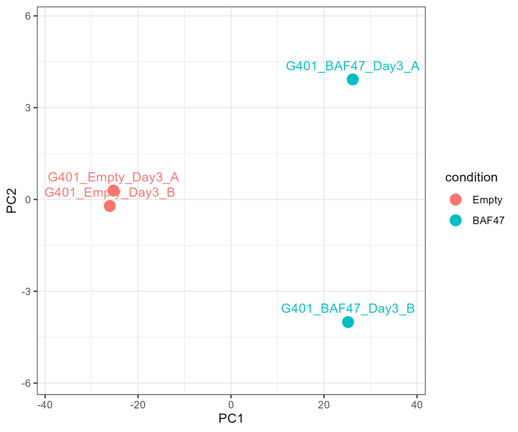

PCA plot

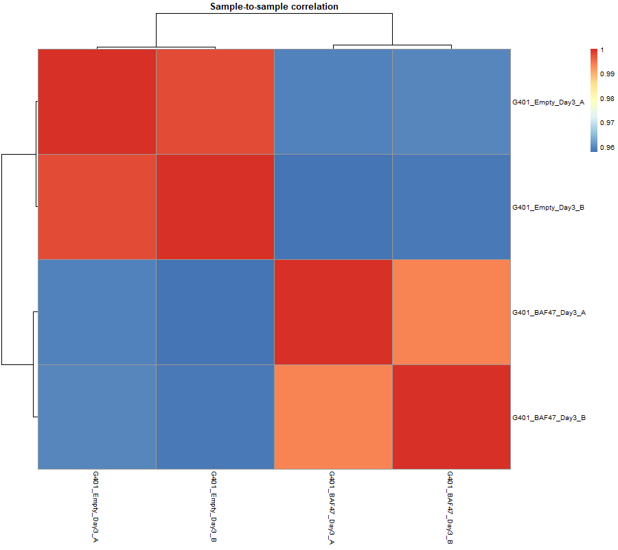

Sample correlation heatmap

## 5.2 Differential expression analysis

A total of **17,220 genes** were tested in the DESeq2 analysis. Among these, **2,314 genes** met the significance criteria used in this project.

Breakdown of significant genes:

- **1,654 genes** were upregulated in `BAF47`
- **660 genes** were downregulated in `BAF47`

This indicates that BAF47 re-expression was associated with widespread transcriptional changes rather than a small targeted response.

### Representative significantly changed genes

Examples of highly significant genes included:

- `LAMB1`
- `LTBP1`
- `FSTL1`
- `TPM1`
- `COL17A1`
- `HEG1`
- `PMEL`
- `FILIP1L`

Among genes with strong positive effect sizes in the `BAF47` condition, the analysis recovered:

- `SMARCB1`
- `ANXA3`
- `MYL4`
- `SLN`
- `KLK6`

Examples of genes with negative log2 fold change in the `BAF47` condition included:

- `PRR20A`
- `PRR20B`
- `PRR20C`
- `PRR20D`
- `PRR20E`
- `FGD2`
- `TAC3`
- `IL23A`

These results support the conclusion that BAF47 re-expression induces a strong shift in the transcriptional state of G401 cells.

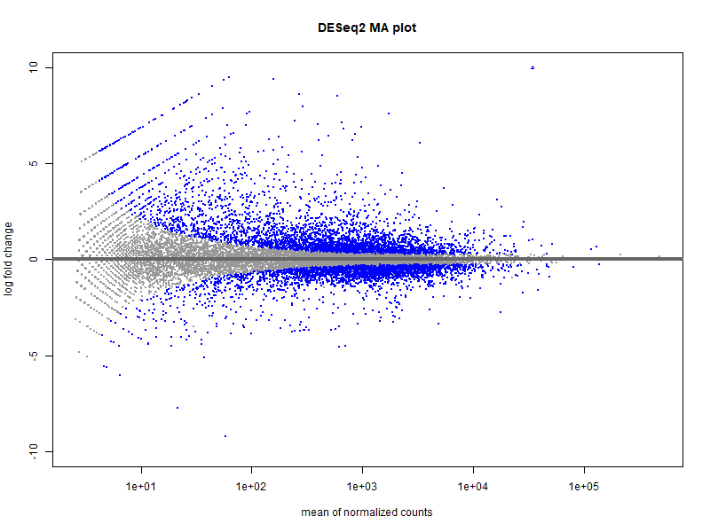

MA plot

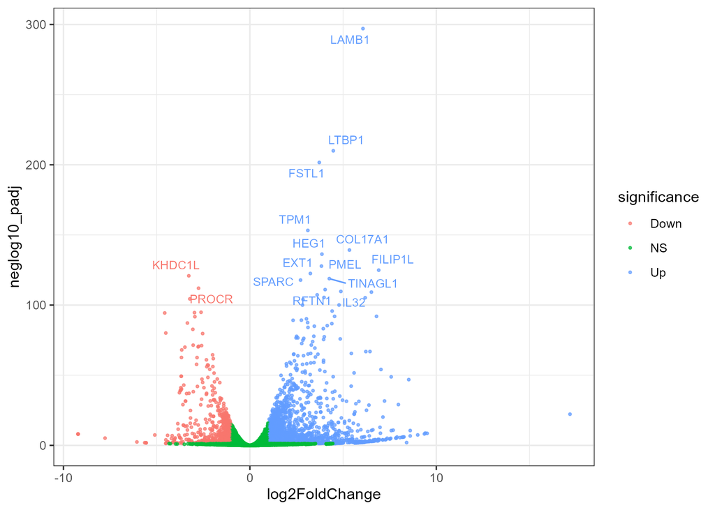

Volcano plot

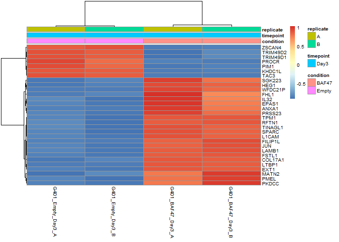

Heatmap of top differentially expressed genes

## 5.3 Hallmark pathway enrichment analysis

Hallmark gene set enrichment analysis further clarified the biological programs associated with the transcriptional shift.

### Positively enriched pathways in the BAF47 condition

The strongest positively enriched Hallmark pathways included:

- **HALLMARK_EPITHELIAL_MESENCHYMAL_TRANSITION**
- **HALLMARK_MYOGENESIS**
- **HALLMARK_ESTROGEN_RESPONSE_EARLY**
- **HALLMARK_APICAL_JUNCTION**
- **HALLMARK_COAGULATION**

These enrichments suggest increased activation of adhesion-related, structural, and differentiation-associated transcriptional programs after BAF47 re-expression.

### Negatively enriched pathways in the BAF47 condition

The strongest negatively enriched Hallmark pathways included:

- **HALLMARK_MYC_TARGETS_V1**
- **HALLMARK_MYC_TARGETS_V2**
- **HALLMARK_E2F_TARGETS**
- **HALLMARK_G2M_CHECKPOINT**
- **HALLMARK_DNA_REPAIR**

These results are consistent with reduced activity of proliferation-associated and cell-cycle-associated programs in the BAF47 condition.

## 6. Interpretation

Taken together, the results indicate that **SMARCB1/BAF47 re-expression drives broad transcriptional remodeling in G401 malignant rhabdoid tumor cells**.

At the gene-expression level, the effect is strong enough to separate the two conditions clearly by PCA and to produce more than two thousand significant gene-level changes under the chosen threshold. At the pathway level, the enrichment pattern suggests a shift away from proliferative programs such as **MYC**, **E2F**, and **G2M checkpoint** activity and toward programs linked to structural remodeling, adhesion, and differentiation-associated states.

Because this project is based on a single cell line and a single time point, the biological interpretation should remain appropriately conservative. However, the overall pattern is consistent with BAF47 acting as a major regulator of transcriptional state in this system.

## 7. Reproducibility and outputs

This project was organized as a stepwise and reproducible R-based workflow with separate scripts for:

1. count matrix construction
2. QC and PCA
3. DESeq2 analysis
4. visualization
5. Hallmark GSEA

Main outputs included:

- `count_matrix.csv`
- `library_size.csv`
- `pca_coordinates.csv`
- `sample_correlation_matrix.csv`
- `deseq2_results_all.csv`
- `deseq2_results_sig.csv`
- `Hallmark_fgsea_results.csv`
- PCA, MA, volcano, and heatmap figures

## 8. Limitations

This first version has several important limitations:

1. **Small sample size**  
   Only four samples were included in this initial analysis.
2. **Single cell line**  
   The current report focuses only on G401 cells.
3. **Single time point**  
   Only Day 3 samples were analyzed.
4. **Transcriptome-only scope**  
   The analysis does not yet integrate other modalities such as chromatin accessibility, ChIP-seq, or additional perturbation conditions.
5. **No external validation in this version**  
   Findings are based on internal differential expression and enrichment analyses only.

These limitations do not invalidate the analysis, but they define the current report as a focused first-pass transcriptomic summary rather than a fully expanded biological study.

## 9. Recommended next steps

Reasonable extensions of this project include:

- adding **G401 Day 7** samples
- adding **TTC1240** samples
- modeling **timepoint effects**
- integrating additional genomic or chromatin datasets
- locking the R environment for stricter reproducibility
- converting the workflow into a polished final Quarto report

## 10. Conclusion

This project demonstrates a compact but complete bulk RNA-seq analysis workflow for studying the transcriptional impact of **SMARCB1/BAF47 re-expression** in **G401 malignant rhabdoid tumor cells**.

The main findings of this first version are:

- condition-level separation by PCA
- thousands of significant gene-level changes
- strong pathway-level evidence for repression of MYC/E2F/cell-cycle programs
- enrichment of structural and differentiation-associated pathways after BAF47 re-expression

As a portfolio project, this analysis provides evidence of practical skills in:

- transcriptomics data handling
- statistical analysis in R
- DESeq2-based differential expression
- pathway analysis
- figure generation
- reproducible project organization